# midterm2

Author

Karli Balzanto

```r
library(tidyverse)
library(readr)
summerschool <- read_csv("summer_school.csv")
cupid <- read_csv("cupid.csv")
```

- open resource exam
- free to work with others but **NOT** ask for answers using outside sources (including people and programs)
- use tools discussed in class
- follow all best practices established in class
- has to be functional and have clarity & style

## problem 1

Tidy the data & recreate the given plot as closely as possible.

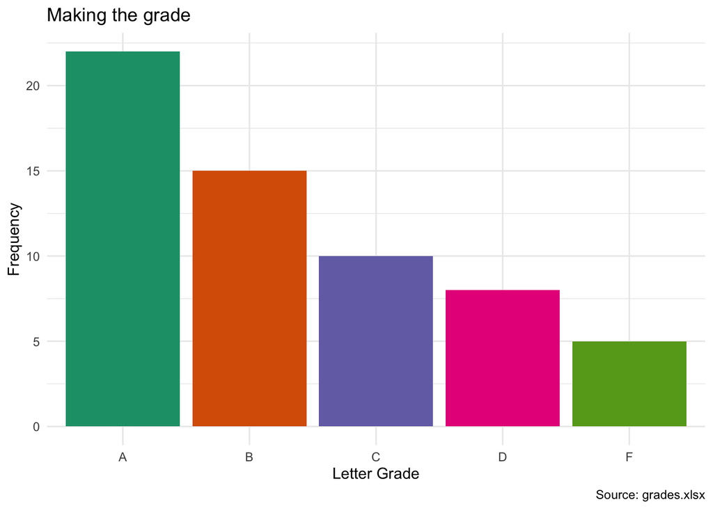

```r
terms <- summerschool %>%
  pivot_longer(cols = c(term1, term2),
               names_to = "term",
               values_to = "grade") %>%
  drop_na(grade)

ggplot(terms, aes(x = grade,
                         fill = grade)) +
  geom_bar(show.legend = FALSE) +
  labs(title = "Making the grade",
       x = "Letter Grade",
       y = "Frequency",
       caption = "Source: grades.xlsx") +
  scale_fill_brewer(palette = "Dark2") +
  theme_minimal()
```

## problem 2

high school claims avg GPA = 3.1. Is the claim reasonable?

$H_0: \mu = 3.1$ (true mean GPA of students taking summer school is 3.1)

$H_a: \mu \ne 3.1$ (true mean GPA of students taking summer school is not 3.1)

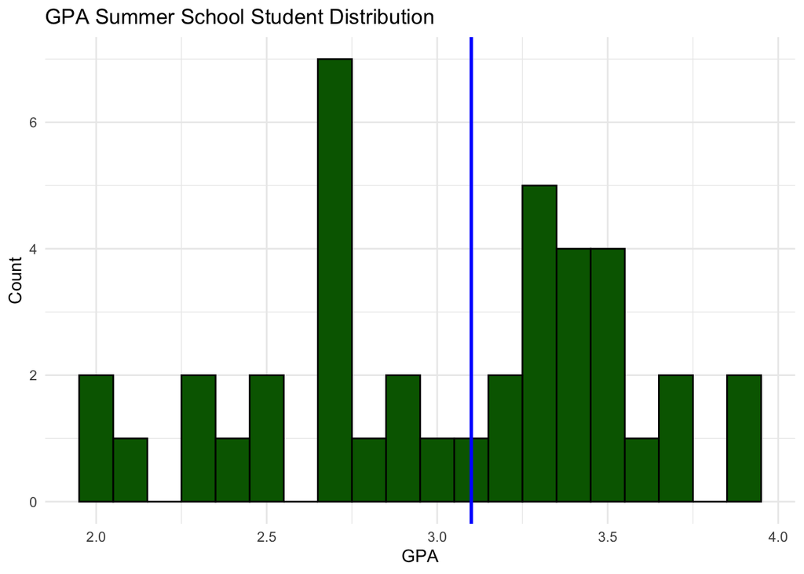

```r
ggplot(summerschool, aes(x = gpa,
                         fill = gpa)) +
  geom_histogram(binwidth = 0.1,
                 fill = "darkgreen",
                 color = "black") +
  geom_vline(xintercept = 3.1,
             color = "blue",
             linewidth = 1) +
  labs(title = "GPA Summer School Student Distribution",
       x = "GPA",
       y = "Count") +
  theme_minimal()
```

```r
t.test(summerschool$gpa, mu = 3.1)
```

```
    One Sample t-test

data:  summerschool$gpa
t = -0.91614, df = 39, p-value = 0.3652
alternative hypothesis: true mean is not equal to 3.1
95 percent confidence interval:
 2.859412 3.190588
sample estimates:
mean of x
    3.025
```

**Plain English Explanation:** The students have an average GPA of 3.025 which is very close to the school’s claimed avarage of 3.1. The difference is small and likely just a normal variation so we don’t have convincing envidence that the school’s claim is inaccurate.

**Statistical Explanation:** The sample of 40 students has a mean GPA of 3.025 (rounded 3.0). The t-test showed a p-value of 0.365, because of that, we fail to reject the null hypothesis. There is not enough statistical evidence to conclude the true mean GPA differs from 3.1.

## problem 3

Recreate given table as closely as possible.

```r
library(gt)

gt_table <- summerschool %>%
  pivot_longer(cols = c(term1, term2),
               names_to = "term_type",
               values_to = "Grade") %>%
  drop_na(Grade) %>%
  mutate(Term = str_remove(term_type, "term"),
         DF = if_else(Grade %in% c("D", "F"), 1,0)) %>%
  group_by(Term) %>%
  summarise(Number = n(),
            DF_Rate = mean(DF)) %>%
  gt() %>%
  cols_label(Term = "Term",
             Number = "Number",
             DF_Rate = "DF Rate") %>%
  fmt_number(columns = c(DF_Rate),
             decimals = 2)
gt_table
```

| Term | Number | DF Rate |
| --- | --- | --- |
| 1 | 40 | 0.10 |
| 2 | 20 | 0.45 |

## problem 4

Does it seem the body type & drug use are related? Consider only the five most common body types & only people that answered these questions.

Generate a plot and a table, both useful and attractive, then give a few sentences explaining findings and reasoning. (not statistical inference)

```r
cupid_sm <- cupid %>%
  filter(!is.na(body_type),
         !is.na(drugs)) %>% # no NA's / only people who answered
  filter(body_type %in% (count(.,
                               body_type,
                               sort = TRUE) %>%
                           slice_head(n = 5) %>%
                           .$body_type)) # 5 most common body types

body_drug_table <- cupid_sm %>%
  count(body_type,
        drugs) %>%
  gt() %>%
  cols_label(body_type = "Body Type",
             drugs = "Drug Use",
             n = "Count")
body_drug_table
```

| Body Type | Drug Use | Count |
| --- | --- | --- |
| athletic | never | 197 |
| athletic | often | 1 |
| athletic | sometimes | 29 |
| average | never | 238 |
| average | sometimes | 43 |
| curvy | never | 72 |
| curvy | sometimes | 19 |
| fit | never | 194 |
| fit | sometimes | 40 |
| thin | never | 70 |
| thin | often | 1 |
| thin | sometimes | 26 |

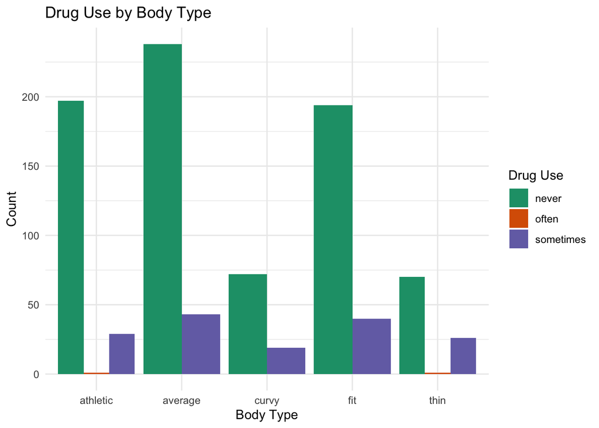

```r
ggplot(cupid_sm,
       aes(x = body_type,
           fill = drugs)) +
  geom_bar(position = "dodge") +
  labs(title = "Drug Use by Body Type",
       x = "Body Type",
       y = "Count",
       fill = "Drug Use") +
  scale_fill_brewer(palette = "Dark2") +
  theme_minimal()
```

From the table and plot, I found the following information:

- The bar plot makes it easier to compare the categories while the table provides exact counts for the bar plot.
- Some body types have higher `never` counts of drug use than others, indicating there’s a difference in drug usage by body type.
- The athletic and fit body types are very similar in counts for each `drug use` category.
- (if this is subjective/not verified by a test) The data shows that almost all the participants didn’t admit to any drug usage. This would make a lot sense of no admittance to any if there was no protection from the law or ability to be anonymous.
- Behavioral patterns differ from group sizes. This can be show by changing the parameters in `geom_bar()`.
  - When the bar chart has nothing in the parenthesis, the total number of individuals in each body type goes from curvy –> thin –> athletic –> fit –> average. This shows that average and fit body types are the most common, while curvy and this are the least common body types in the data set.
  - When the bar chart has `position = "fill"` (show the proportions of each drug use category), the `never` drug use category increases from thin –> curvy –> fit –> average –> athletic. This means that athletic individuals have the highest rate of never using drugs even if the total counts differ.
  - Both these findings explain that the sample is concentrated to a certain body type but the drug use patterns vary across the body types independently of how many individuals are in each group meaning that body type aline doesn’t determine drug use behavior, and differences aren’t just due to group size.

## problem 5

Is the cupid data set consistent with the Gallup findings (U.S adult identification: 3.4% gay, 5.2% bisexual, & 91.4% straight)?

$H_0:$ The proportions of gay, bisexual, and straight individuals match Gallup’s reported percentages (3.4%, 5.2%, and 91.4% respectively).

$H_a:$ The proportions of gay, bisexual, and straight individuals do not match Gallup’s reported percentages.

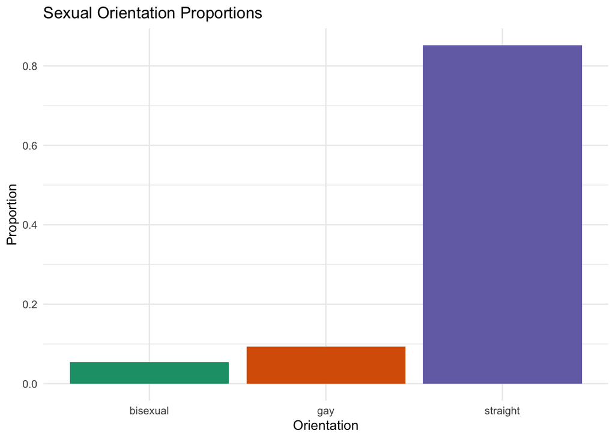

```r
#visual
orientation_sum <- cupid %>%
  filter(!is.na(orientation)) %>%
  count(orientation) %>%
  mutate(proportions = n / sum(n))

ggplot(orientation_sum,
       aes(x = orientation,
           y = proportions,
           fill = orientation)) +
  geom_col(show.legend = FALSE) +
  labs(title = "Sexual Orientation Proportions",
       x = "Orientation",
       y = "Proportion") +
  scale_fill_brewer(palette = "Dark2") +
  theme_minimal()
```

```r
Obs <- cupid %>%
  filter(!is.na(orientation)) %>% #no NAs
  count(orientation) %>% #total for each
  arrange(orientation) %>% #order = bi, gay, straight
  .$n #extract count

p_null <- c(0.052, 0.034, 0.914) #bi, gay, straight

chisq.test(Obs, p=p_null)
```

```
    Chi-squared test for given probabilities

data:  Obs
X-squared = 160.68, df = 2, p-value < 2.2e-16
```

**Plain English Explanation:** The proportions of sexual orientations in the Cupid data set are far from the Gallup percentages for U.S. adults. The differences are much larger than what would normally happen just from random chance. That means we have strong evidence that the Cupid sample does not match the national distribution of straight, gay, and bisexual adults. In practical terms, the Cupid users in this data set simply represent a different mix of people than what Gallup sees in the general population.

**Statistical Explanation:** The chi-squared test compares the Cupid sample proportions to the Gallup population proportions (91.4% straight, 3.4% gay, 5.2% bisexual). After removing missing values and calculating expected counts, the test produced a very large chi-squared value and a p-value near zero. Because the p-value is so small, we reject the null hypothesis that the Cupid sample follows the Gallup proportions. This provides strong statistical evidence that the observed orientation distribution is not consistent with the Gallup distribution.

## problem 6

Get an attractive plot showing the six most common responses. Use `separate`, `case_when`, and core tools to obtain accurate counts of various individual ethnicities represented in this data set.

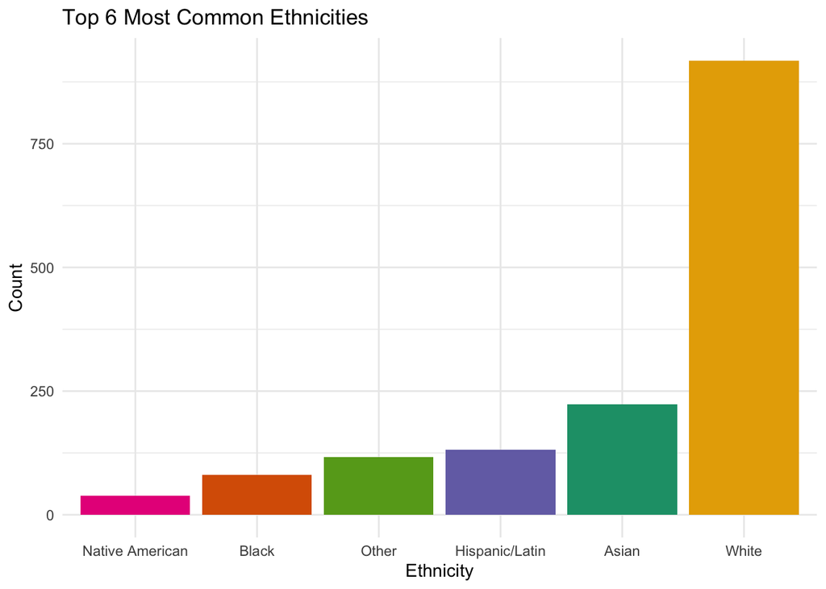

```r
eth_clean <- cupid %>%
  filter(!is.na(ethnicity)) %>% #remove NAs
  separate_longer_delim(ethnicity, delim = ",") %>% #had to look up what to do if gave multiple/dilema situation
  mutate(ethnicity = str_trim(ethnicity),
         ethnicity = case_when(ethnicity %in% c("asian") ~ "Asian",
                               ethnicity %in% c("white") ~ "White",
                               ethnicity %in% c("black") ~ "Black",
                               ethnicity %in% c("hispanic / latin", "hispanic/latin") ~ "Hispanic/Latin",
                               ethnicity %in% c("middle eastern") ~ "Middle Eastern",
                               ethnicity %in% c("native american") ~ "Native American",
                               ethnicity %in% c("pacific islander") ~ "Pacific Islander",
                               ethnicity %in% c("other") ~ "Other",
                               TRUE ~ "Other"))

eth_counts <- eth_clean %>%
  count(ethnicity, sort = TRUE) %>%
  slice_max(n, n = 6)

ggplot(eth_counts,
       aes(x = reorder(ethnicity, n),
           y = n,
           fill = ethnicity)) +
  geom_col(show.legend = FALSE) +
  labs(title = "Top 6 Most Common Ethnicities",
       x = "Ethnicity",
       y = "Count") +
  scale_fill_brewer(palette = "Dark2") +
  theme_minimal()
```